# 206_Assignment_4_Lobsters

Lydia Bleifuss and Camila Bobroff

11/15/18

## Analyzing California Spiny Lobster Abundance, Size and Fishing Implications

### A brief assessment conducted with Spiny Lobster samples taken from five sites in the Santa Barbara Channel from 2012 through 2017

Lydia Bleifuss & Camila Bobroff

Bren School of Environmental Science and Management

University of California, Santa Barbara

#### Introduction

Southern California’s Spiny Lobster has been fished commercially since the 1800s. The Santa Barbara Channel Spiny Lobster fishery is one of California’s most economically critical, and has also undergone concerning population changes within the last decade.2 Spiny Lobster were being harvested at record rates from the late 2000s to 2010. Improvements in fishing technology and increases in recreational fishing however, combined with an observed 15% decline in reported lobsters caught, necessitated improved monitoring.2

The Santa Barbara Coastal Long Term Ecological Research Project (SBC LTER), operating within University of California, Santa Barbara, has lead data collection surrounding this topic in conjunction with the National Science Foundation’s Long Term Ecological Research Network since the 1980s. In 2012, five Santa Barbara Coastal sites which were established close to the mainland: Arroyo Quemado (AQUE), Naples Reef (NAPL), Mohawk Reef (MOHK), Isla Vista (IVEE), and Carpinteria (CARP). Of those, Naples and Isla Vista were designated no-take marine protected areas (MPAs). MPAs, or oceanic corridors defined by boundaries in which human activity is limited and fishing is restricted, are established to promote marine biodiversity. In some cases, MPA parameters are selected with specific species targets in mind.1

Although, Spiny Lobster size, abundance, and fishing pressure in the Santa Barbara Chanel has been monitored since 2012, overall lack of previously collected data for this fishery confines analysis relative to recent years.3 In this report, we utilize data that has been collected by the SBC LTER project from 2012 through 2017 at the five sites. The purpose of this analysis is to describe lobster abundance and size relative to trapping presence and to determine the significance of MPA designation in relation to lobster size and abundance over time.

#### Data Analysis and Statistical Methods

Our data was collected by dive teams from 2012 through 2017 and summarized by Daniel Reed via SBC.3 The dataset produced two tables, the first indicating lobster abundance and size (carapace length in mm) collected at the five LTER sites annually before the start of the fishing season in late summer. The second displays the number of commercial trap floats in each site, indicating fishing pressure. Every two to four weeks throughout the October to March fishing season, total trap counts are collected at the five LTER sites and four additional sites near the mainland. Eight of the nine sites are LTER. For the purposes of our analysis, we will only be utilizing the five LTER sights included across both tables.

The information compiled in this dataset including date, site, site location and MPA designation, lobster length (mm) and relative count, and total trap counts per site, was utilized to calculate mean sample statistics. We used this data to detect any associations between lobster abundance and fishing pressure throughout the data collection years, compare mean lobster size across the 5 sites in 2017, changes in mean size at MPA and non-MPA sites between 2012 and 2017, and the proportion of legal lobsters at all 5 sites in 2017. More specifically, we used a one-way ANOVA with a post-hoc Tukey’s HSD test to compare mean lobster sizes, and used both one-sided and two-sided two sample Student’s T-tests (α = 0.025 and α = 0.05 respectively) to determine significance or lack thereof for changes in lobster size. Our analysis, including graphs and tables, was produced using R Statistical Software through R Studio (v. 1.1456).

### Results and Discussion

#### *Lobster abundance and fishing pressure (2012 - 2017)*

To gain an initial impression of lobster abundance and fishing pressure we compared all five sites, MPA and non-MPA, contrasting relative abundance and trap total data. No traps were observed at the two MPA sites, Isla Vista and Naples Reef, from 2012 to 2017. Overall increases in Isla Vista and Carpinteria lobster abundance is notable, and dramatically so from 2016 to 2017. However, while Carpinteria trap totals decreased significantly from 2016-2017, Isla Vista totals remained constant at zero. Despite 2015 count peaks for Mohawk and Naples, abundance levels at Mohawk Reef and Naples Reef lobster in 2017 are relatively lower than Isla Vista and Carpinteria. All three non-MPA sites appear to decrease trap totals from 2016 to 2017. Despite Isla Vista and Naples MPA designation, abundance at these two sites does not appear to react similarly year to year.

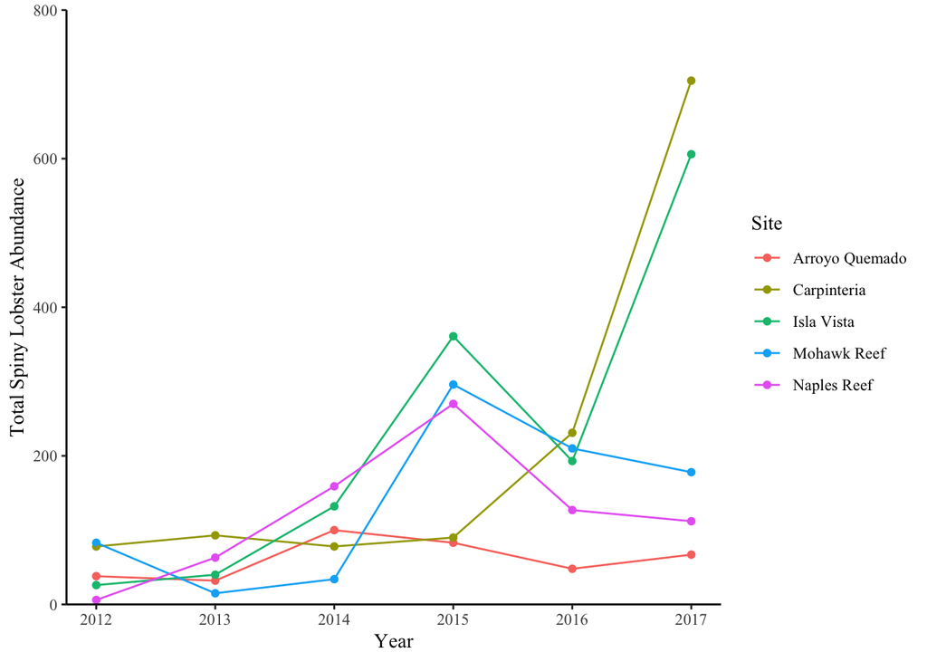

**Figure 1. Lobster Abundance in the Santa Barbara Channel (2012 - 2017).**  
Counts of California spiny lobster collected annually in late summer before the fishing season. Data used with permission from SBC LTER<sup>3</sup>.

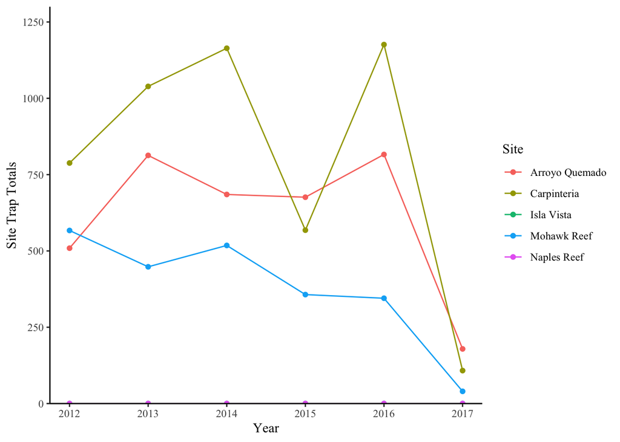

**Figure 2. Lobster Traps in the Santa Barbara Channel (2012 - 2017).**  
Counts of commercial trap floats collected every two to four weeks during the fishing season. Data used with permission from SBC LTER<sup>3</sup>.

##### *Compare mean lobster size by site in 2017*

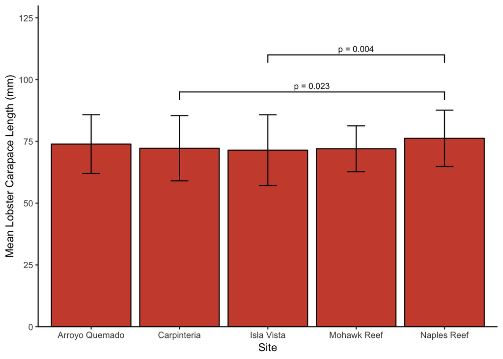

| Site | Mean Carapace Length (mm) | Standard Deviation (mm) | Sample Size |
| --- | --- | --- | --- |
| Arroyo Quemado | 73.90 | 11.89 | 67 |
| Carpinteria | 72.23 | 13.21 | 705 |
| Isla Vista | 71.45 | 14.32 | 606 |
| Mohawk Reef | 72.00 | 9.28 | 178 |
| Naples Reef | 76.23 | 11.39 | 112 |

**Table 1. Mean lobster size summary by site (2017).**

Data source: SBC LTER<sup>3</sup>.

Data source: SBC LTER<sup>3</sup>.

**Figure 3. Mean Lobster Size in the Santa Barbara Channel (2017)**  
2017 mean lobster carapace length (mm) by site, measured in late summer before the fishing season. Error bars indicate ± 1 standard deviation. Brackets indicate *p*-values for significantly different means as determined by one-way ANOVA (F(4, 1663) = 3.4, *p* = 0.009, $\alpha$ = 0.05) with post-hoc Tukey’s HSD ($\alpha$ = 0.05). Data used with permission from SBC LTER<sup>3</sup>.

##### *Proportions of “legal” lobsters at the 5 sites in 2017*

There is a significant association between observed lobsters above or below the legal limit (82.6 mm) and location ($\chi^2${4} = 18.50, *p* = 0.001). Notably, lobsters above the legal limit at Naples Reef, an MPA site, (33%) was remarkably higher than those observed at Mohawk Reef, a non-MPA site (13%). However, the proportion of Isla Vista lobsters above the legal limit (21%), was not higher than both Arroyo Quemado (24%) and Carpinteria (25%). These results indicate that MPA designation does not have an absolute association with lobsters surpassing the 82.6 mm legal requirement.

### Conclusion

The Santa Barbara Channel Spiny Lobster fishery remains an important economic hub, but also an intricate habitat and budding recreational playground. In order to properly promote both the societal benefits Spiny Lobsters provide and the species itself, data collection of lobster abundance and size must be further prioritized. In the Santa Barbara Channel, both commercial fisheries and marine governance authorities need to incorporate a better understanding of what factors influence fluxes in lobster count and size, and how such factors can be managed. Despite lack of apparent patterns between lobster abundance, size and fishing pressure throughout the first five years of data collection, continued and improved monitoring in the Channel is necessary to provide a clearer representation of associations between human influences and lobsters populations.

**The following statements summarize the main results of our analysis:**

1. *All five site abundance levels appeared to respond differently to either changes in trap presence or consistently prohibited trapping from 2012 to 2017, and with no apparent association between MPA or non-MPA designation.*
2. *Although lobster carapace length differed significantly between the five sites in 2017, this result did not indicate that MPA designation is associated with lobster size.*
3. *Lobster carapace length compared between 2012 and 2017, indicates that lobsters at non-MPA sites decreased in size.*
4. *Proportions of lobsters above and below the legal limit of 82.6 mm found at each of the five sites in 2017 differed significantly, however the results do not indicate that MPA sites contain more legal lobsters than non-MPA sites.*

Greater comprehension of Spiny Lobster population health in the Santa Barbara Channel would be promoted through increased data collection. Three out of the four results above not only indicate no significant results regarding associations between lobster abundance, size and fishing pressure, but in fact reveal some contradicting trends between the two MPA designated sites. This may be in part due to erratic and often small sample sizes, for example, 6 lobsters counted at Naples Reef in 2012, and a low number of sites. Without more MPA designated sites to compare to non-MPA, results are highly limited to Naples and Isla Vista. As each site can be influenced by a multitude of factors, any data analysis is less significant. Our analysis and report should not only be conducted yearly, but with heightened data collection in partnership with a greater number of sites to compare, both MPA and non-MPA.

As commercial fishing continues, coupled with recreational harvesting and climate uncertainties, the protection of the Santa Barbara Channel Spiny Lobster fishery depends on improved data collection, responsible analysis, and informed marine governance responses.

### References

1. Kay, Matthew C., Hunter S. Lenihan, Matthew J. Kotchen, and Christopher J. Miller (2012). Effects of Marine Reserves on California Spiny Lobster Are Robust and Modified by Fine-Scale Habitat Features and Distance from Reserve Borders. Marine Ecology Progress Series 451. Retrieved November 2018, from 137–50. https://doi.org/10.3354/meps09592.
2. Miller, E. (2014). Status and Trend in the Southern California Spiny Lobster Fishery and Population: 1980-2011. Bulletin of the Southern California Academy of Sciences. Retrieved November 2018, from https://scholar.oxy.edu/scas/vol113/iss1/2.
3. Reed, D. (2017). SBC LTER: Reef: Abundance, size and fishing effort for California Spiny Lobster (Panulirus interruptus), ongoing since 2012. Santa Barbara Coastal Long Term Ecological Research Project. Retrieved November 2018, from http://sbc.lternet.edu/cgi-bin/showDataset.cgi?docid=knb-lter-sbc.77